# MAT02026 - Inferência B

12 August 2019

## Apresentação

- Qual o seu nome?
- Quantas/quais disciplinas esse semestre?
- O que é estatística/inferência?
- O que espera da disciplina?

## O que é (Inferência) Estatística?

[figure not shown]

[figure not shown]

## O que é (Inferência) Estatística?

[figure not shown]

[figure not shown]

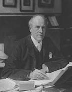

[figure not shown]

## O que é (Inferência) Estatística?

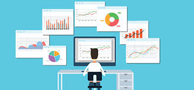

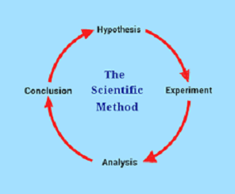

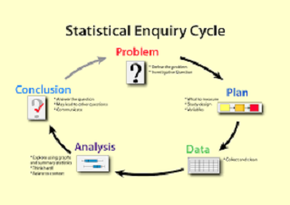

## O que é (Inferência) Estatística?

**Tipos de inferência**  
- dedutiva \(\times\) indutiva

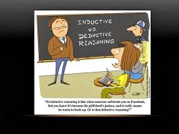

[figure not shown]

[figure not shown]

[figure not shown]

## Inferência indutiva \(\times\) dedutiva

- Experimentos **determinísticos** \(\times\) **aleatórios** (estocásticos);
- Modelo **probabilístico**: intepretação de probabilidade **frequentista** \(\times\) **subjetiva**.

Ex.: Estamos interessados na probabilidade de cara em um lançamento de uma moeda honesta;

Interpretação **frequentista**: Essa probabilidade é "50%", pois se realizássemos o experimento um grande número de vezes, esperaríamos…;

**Subjetiva**: Essa probabilidade é "50%", pois em um lançamento honesto de uma moeda honesta creio que os dois possíveis resultados sejam equiprováveis.

- Modelo **estatístico**: o que significa probabilidade no mundo real?

## Inferência Estatística

- **Parâmetro** de interesse? Inferência **paramétrica** \(\times\) **não paramétrica**;

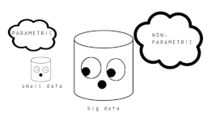

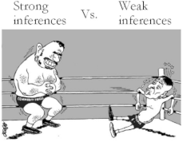

- Escolas **frequentista** e **Bayesiana** de pensamento estatístico.

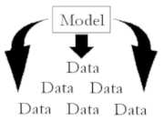

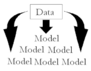

- Observação: coleta de **Dados**!!!

## Exemplo 1:

- Qual a prevalência (proporçãao) de crianças com excesso de peso no RS?
- Podemos chamar essa proporção de \(\theta\).
- O que sabemos a respeito de \(\theta\)?
- Qual a nossa incerteza a respeito de \(\theta\)?
- \(\theta\) por ser uma proporção está entre 0 e 1. É provável que esteja próximo de 0? E de 1? E de 0.25?
- Podemos construir uma distribuição de probabilidades que represente o nosso conhecimento?
- Será que podemos atualizar nosso conhecimento usando dados?

## Qual a nossa incerteza a respeito de \(\theta\)?

- **Intervalo de confiança** e **testes de hipóteses**
- Exemplo interpretação intevalos de confiança - https://rpsychologist.com/d3/CI/
- Intervalo de confiança bootstrap - https://www.youtube.com/watch?v=iN-77YVqLDw

Teorema - Sejam \(X_1, \ldots, X_n\) variáveis aleatórias independentes tal que \(X_i \sim Normal(\mu, \sigma^2)\). Então:  
i. \(\overline{X}\) e \(S^2\) são independentes;  
ii. \(\frac{(n-1) S^2}{\sigma^2} \sim \chi^2_{(n-1)}\);  
iii. \(\frac{ \sqrt{n} ( \overline{X} - \mu )}{S} \sim t_{(n-1)}\).  
Prova?

## A disciplina

Plano de ensino: ler!!!

Nota final = 90% provas e trabalho + 10% listas

Livros  
- busca no [SABI](http://sabi.ufrgs.br/)

[figure not shown]

## Mais informações

Slides  
- não dispensam a leitura de livros!

Material de apoio  
- apostila e livros!

Monitoria - Monitoria presencial com o professor. Horário de atendimento… sala B120.

Exercícios e software?  
- [R](https://www.r-project.org/) + [Rstudio](https://www.rstudio.com/)

## Um pouco de história, filosofia e atualidade

[figure not shown]

- https://www.bbc.com/news/science-environment-47267081

## Inferência Estatística na era computacional

- AAAS: Machine learning 'causing science crisis' https://www.bbc.com/news/science-environment-47267081
- Statistics, Fake News, and AI: Who’s on First? http://magazine.amstat.org/blog/2019/03/01/fakenews/
- LIVRO - Computer Age Statistical Inference: Algorithms, Evidence and Data Science https://web.stanford.edu/~hastie/CASI/index.html

## Próxima aula

- Ler o material no moodle!
- Realizar as atividades propostas!

**Bom semestre a todos!**